# Dota2_Analysis_and_Results

Louis MS

22/03/2017

This document takes the previous work done in ‘Dota2_Data_Wrangling.Rmd’ which produced the data frame ‘CombinedDF’. Lets take a quick look as a reminder of the variables collected.

```r
# Read in 'CombinedDF.csv' file
CombinedDF <- read.csv(file = "CombinedDF.csv")

# Glimpse at 'CombinedDF'
glimpse(CombinedDF)
```

```
## Observations: 420,510
## Variables: 52
## $ X                         <int> 1, 2, 3, 4, 5, 6, 7, 8, 9, 10, 11, 1...
## $ match_id                  <int> 0, 0, 0, 0, 0, 0, 0, 0, 0, 0, 1, 1, ...
## $ start_time                <int> 1446750112, 1446750112, 1446750112, ...
## $ duration                  <int> 2375, 2375, 2375, 2375, 2375, 2375, ...
## $ tower_status_radiant      <int> 1982, 1982, 1982, 1982, 1982, 1982, ...
## $ tower_status_dire         <int> 4, 4, 4, 4, 4, 4, 4, 4, 4, 4, 1846, ...
## $ barracks_status_dire      <int> 3, 3, 3, 3, 3, 3, 3, 3, 3, 3, 63, 63...
## $ barracks_status_radiant   <int> 63, 63, 63, 63, 63, 63, 63, 63, 63, ...
## $ first_blood_time          <int> 1, 1, 1, 1, 1, 1, 1, 1, 1, 1, 221, 2...
## $ game_mode                 <int> 22, 22, 22, 22, 22, 22, 22, 22, 22, ...
## $ radiant_win               <fctr> True, True, True, True, True, True,...
## $ date                      <fctr> 2015-11-05 19:01:52, 2015-11-05 19:...
## $ account_id                <int> 0, 1, 0, 2, 3, 4, 0, 5, 0, 6, 0, 7, ...
```

[output cut: 39 more lines]

## Gold Accumulation - Linear Regression Models

In this section we will address the question:

“How do I finish with a good amount of gold as a proxy to being ‘sucessful’ in the game?”

let’s first look at how gold compares to match duration.

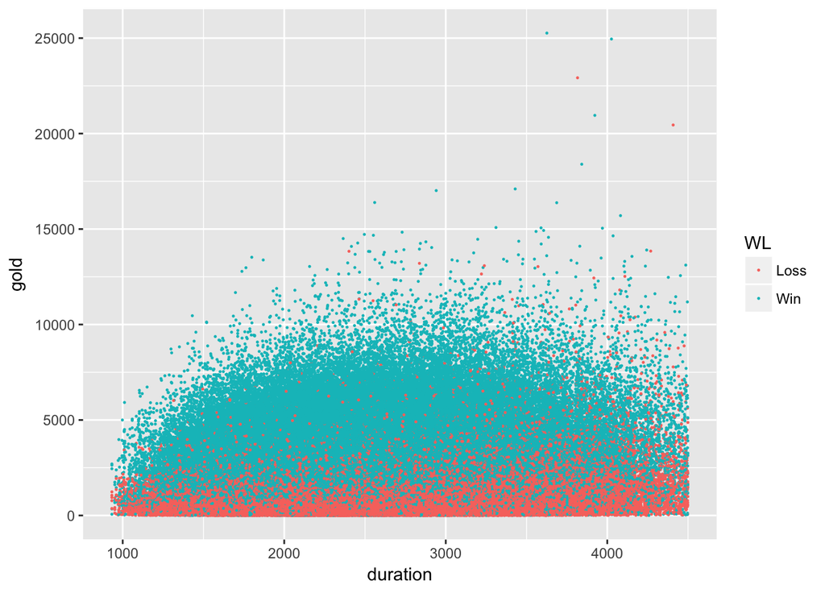

```r
# XY plot of duration against gold
ggplot(CombinedDF, aes(x = duration, y = gold, col = WL)) +
  geom_point(size = 0.2)
```

Here we see quite a broad range of gold values for different durations. Lets look at some heroes individually to see if we can clean up the analysis. Lets take a look at heroes’ popularity and the percentage of matches they tend to win.

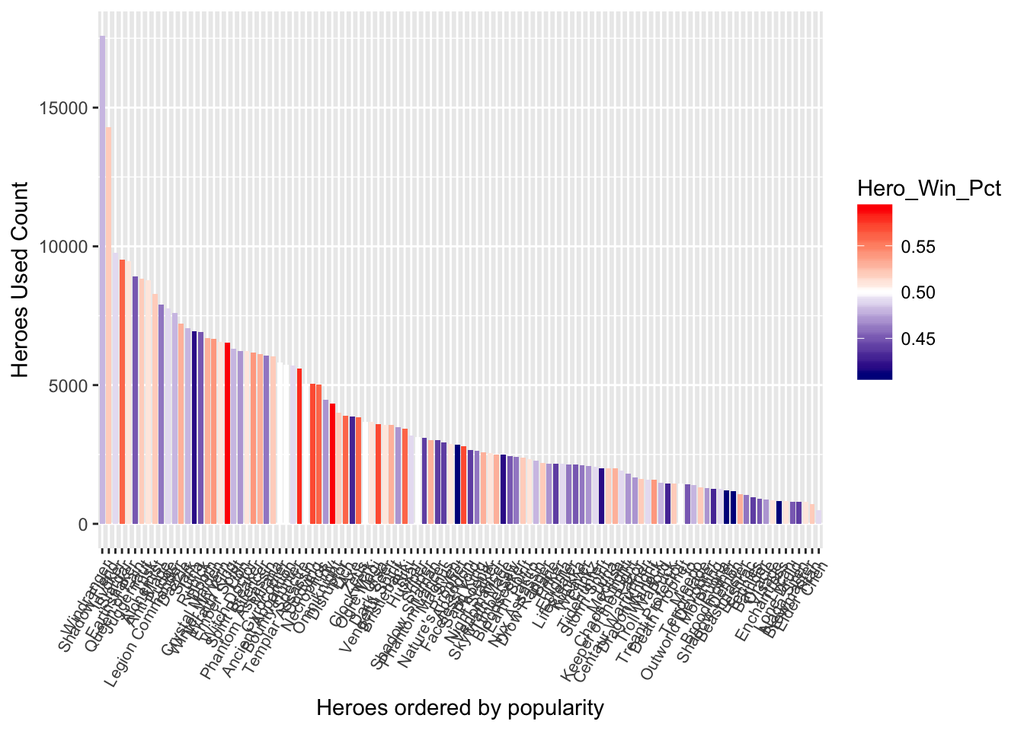

```r
# bar plot for most popular hero names
Hero_Bar <- CombinedDF %>%
  group_by(Hero_Names, Class, Role_Count, All_Roles) %>%
  tally(sort = TRUE) %>%
  rename(Name=Hero_Names, HN_Count=n)

# Heroes win percentage (HWin_Pct)
HWin_Pct <- CombinedDF %>%
  group_by(Hero_Names, WL) %>%
  tally() %>%
  spread(key = WL, value = n) %>%
  rename(Name=Hero_Names) %>%
  mutate(Hero_Win_Pct = round(Win/(Win + Loss), digits = 2))

Hero_Bar <- left_join(Hero_Bar, HWin_Pct, by = "Name")

# ggplot of heroes ordered by popularity and color by their win percentage
ggplot(Hero_Bar, aes(x = reorder(Name, -HN_Count), y = HN_Count, width = 0.8, fill = Hero_Win_Pct)) +
  scale_fill_gradient2(low = "dark blue", high = "red", mid = "white", midpoint = 0.5) +
  geom_bar(stat = "identity") +
    theme(axis.text.x = element_text(angle = 60, hjust = 1, size = 8)) +
  xlab("Heroes ordered by popularity") +
  ylab("Heroes Used Count")
```

This plot show a significant level of popularity over other heroes for the top two most popular; Windranger and Shadow Fiend. It is also noted that Windranger loses more than she wins (blue shading indicates a <0.5 value for ‘Hero_Win_Pct’) and Shadow Fiend wins more than he loses (red shading indication >0.5 value for ‘Hero_Win_Pct’), albeit these are both relatively close to the white 0.5 value for ‘Hero_Win_Pct’. Lets also call for the hero with the highest ‘Hero_Win_Pct’, a variable made by ‘win/(win+loss)’.

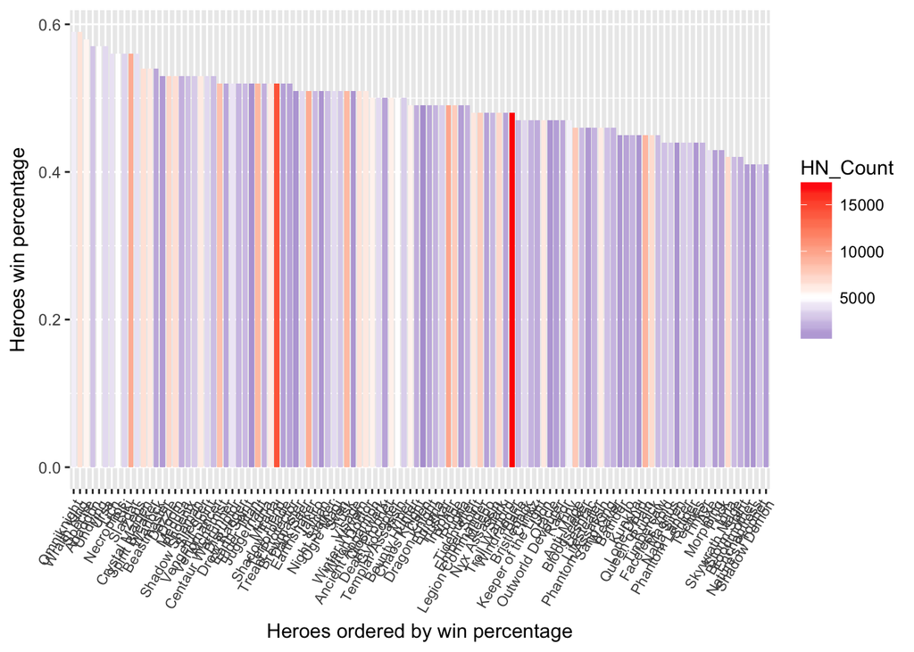

```r
# ggplot of heroes ordered by win percentage and color by their popularity
ggplot(Hero_Bar, aes(x = reorder(Name, -Hero_Win_Pct), y = Hero_Win_Pct, width = 0.8, fill = HN_Count)) +
  scale_fill_gradient2(low = "dark blue", high = "red", mid = "white", midpoint = 5000) +
  geom_bar(stat = "identity") +
    theme(axis.text.x = element_text(angle = 60, hjust = 1, size = 8)) +
  xlab("Heroes ordered by win percentage") +
  ylab("Heroes win percentage")
```

Here we see Omniknight has the highest win percentage of 0.59 . We will also examine this hero to get an indication of how this might vary the model.

### Windranger Linear Model

Lets collect all data on Windranger and look at the duration vs gold XY plot.

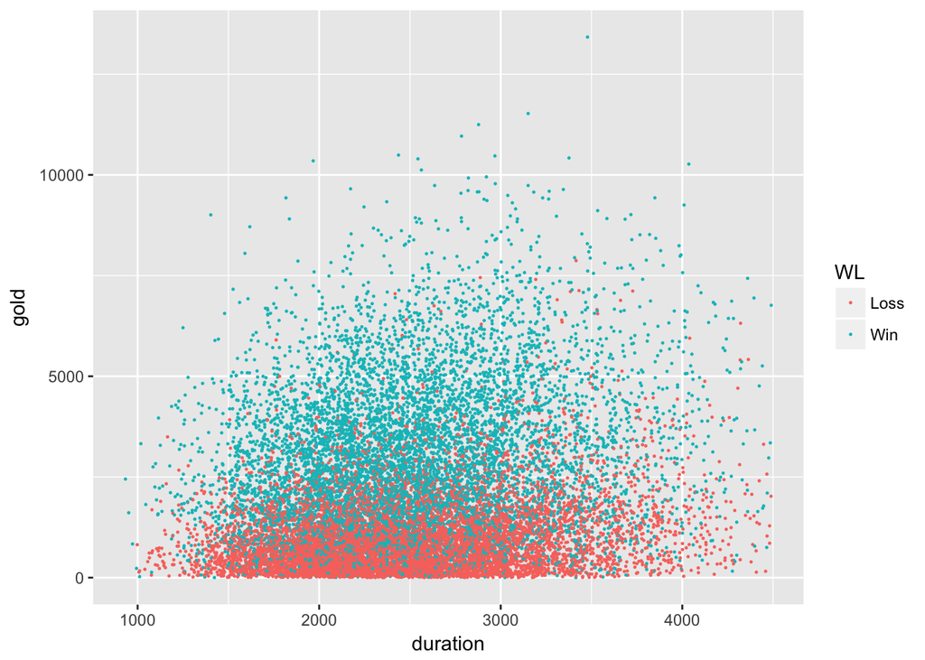

```r
# Selecting all Windranger data
Windranger <- CombinedDF[which(CombinedDF$Hero_Names=="Windranger"),]

# Windranger 'duration' vs 'gold' XY plot
ggplot(Windranger, aes(x = duration, y = gold, col = WL)) +
  geom_point(size = 0.2)
```

This plot shows Windranger’s match duration vs gold, coloured by Win/Loss. The Windranger data frame contains 17597 observations. Let’s look at gold and duration’s linear relationship for Windranger.

```r
# first linear model where 'duration' is used to predict 'gold'
WR_LM1 <- lm(gold ~ duration, data=Windranger)
summary(WR_LM1)
```

```
##
## Call:
## lm(formula = gold ~ duration, data = Windranger)
##
## Residuals:
##     Min      1Q  Median      3Q     Max
## -2678.9 -1240.3  -544.0   854.9 11049.6
##
## Coefficients:
##             Estimate Std. Error t value Pr(>|t|)
## (Intercept) 725.4510    55.2897   13.12   <2e-16 ***
## duration      0.4735     0.0215   22.03   <2e-16 ***
## ---
## Signif. codes:  0 '***' 0.001 '**' 0.01 '*' 0.05 '.' 0.1 ' ' 1
##
## Residual standard error: 1696 on 17595 degrees of freedom
## Multiple R-squared:  0.02683,    Adjusted R-squared:  0.02678
## F-statistic: 485.2 on 1 and 17595 DF,  p-value: < 2.2e-16
```

Model ‘WR_LM1’ shows both the intercept and duration regression coefficient have very low P values, indicating that we can definitely reject the null hypothesis that there is no correlation between these variables. Gold and duration do correlate slightly positively, however the very low R-Squared value of 0.02678 tells us that the model is not very good. Lets see if we can improve this model by including additional variables. Lets add the variable ‘gold_per_min’ to the model as this is directly linked to the gold variable and duration.

```r
# second linear model where 'duration' combined with 'gold_per_min' is used to predict 'gold'
WR_LM2 <- lm(gold ~ duration * gold_per_min, data=Windranger)
summary(WR_LM2)
```

```
##
## Call:
## lm(formula = gold ~ duration * gold_per_min, data = Windranger)
##
## Residuals:
##     Min      1Q  Median      3Q     Max
## -4997.0  -941.6  -235.7   697.3  8032.6
##
## Coefficients:
##                         Estimate Std. Error t value Pr(>|t|)
## (Intercept)            5.212e+02  1.894e+02   2.752  0.00593 **
## duration              -1.001e+00  8.054e-02 -12.432  < 2e-16 ***
## gold_per_min           1.095e+00  4.228e-01   2.589  0.00963 **
## duration:gold_per_min  3.135e-03  1.793e-04  17.490  < 2e-16 ***
## ---
## Signif. codes:  0 '***' 0.001 '**' 0.01 '*' 0.05 '.' 0.1 ' ' 1
##
## Residual standard error: 1450 on 17593 degrees of freedom
## Multiple R-squared:  0.2891, Adjusted R-squared:  0.2889
## F-statistic:  2384 on 3 and 17593 DF,  p-value: < 2.2e-16
```

Model ‘WR_LM2’ displays a low P value for all variables indicating that they correlateas would be expected. The faster a hero collects gold and the longer they have to do this the more gold they are likely to finish with. We also see a significant improvement in the R-squared value to 0.2889 indicating that combining ‘gold_per_min’ with ‘duration’ has really improved the model. Let’s see if we can improve on this model further by adding the ‘gold_spent’ variable as this will most definietly have a significant impact of gold in pocket at match end.

```r
# third linear model where 'duration' combined with 'gold_per_min' plus 'gold_spent' is used to predict 'gold'
WR_LM3 <- lm(gold ~ duration * gold_per_min + gold_spent, data=Windranger)
summary(WR_LM3)
```

```
##
## Call:
## lm(formula = gold ~ duration * gold_per_min + gold_spent, data = Windranger)
##
## Residuals:
##     Min      1Q  Median      3Q     Max
## -5272.6  -693.2   -58.2   637.2  7005.8
##
## Coefficients:
##                         Estimate Std. Error  t value Pr(>|t|)
## (Intercept)            3.287e+02  1.455e+02    2.259   0.0239 *
## duration              -1.121e+00  6.189e-02  -18.119   <2e-16 ***
## gold_per_min           3.286e+00  3.254e-01   10.099   <2e-16 ***
## gold_spent            -5.190e-01  4.696e-03 -110.515   <2e-16 ***
## duration:gold_per_min  9.945e-03  1.509e-04   65.914   <2e-16 ***
## ---
## Signif. codes:  0 '***' 0.001 '**' 0.01 '*' 0.05 '.' 0.1 ' ' 1
##
## Residual standard error: 1114 on 17592 degrees of freedom
## Multiple R-squared:  0.5804, Adjusted R-squared:  0.5803
## F-statistic:  6083 on 4 and 17592 DF,  p-value: < 2.2e-16
```

Model ‘WR_LM3’ shows a very large improvement in R-squared to 0.5803 so that adding ‘gold_spent’ has improved the model significantly. Interestly the P value for the intercept has increased quite a bit, but still remains at a low value of 0.0239.

When a hero In Dota 2 dies the amount of gold is directly tied to their level. Lets add deaths and combine it with xp_per_min. Here we use xp_per_min because it is a continious variable that represents well the discrete variable ‘level’.

```r
# fourth linear model where 'duration' combined with 'gold_per_min', 'gold_spent' and 'deaths' combined with 'xp_per_min' is used to predict 'gold'
WR_LM4 <- lm(gold ~ duration * gold_per_min + gold_spent + deaths * xp_per_min, data=Windranger)
summary(WR_LM4)
```

```
##
## Call:
## lm(formula = gold ~ duration * gold_per_min + gold_spent + deaths *
##     xp_per_min, data = Windranger)
##
## Residuals:
##     Min      1Q  Median      3Q     Max
## -5425.0  -563.1   -44.7   511.6  7318.7
##
## Coefficients:
##                         Estimate Std. Error  t value Pr(>|t|)
## (Intercept)            9.713e+02  1.340e+02    7.249 4.37e-13 ***
## duration              -8.573e-01  5.473e-02  -15.663  < 2e-16 ***
## gold_per_min           1.972e-01  3.160e-01    0.624    0.533
## gold_spent            -5.991e-01  4.222e-03 -141.908  < 2e-16 ***
## deaths                -3.386e+00  8.959e+00   -0.378    0.706
## xp_per_min             1.456e+00  1.718e-01    8.475  < 2e-16 ***
## duration:gold_per_min  1.172e-02  1.342e-04   87.336  < 2e-16 ***
## deaths:xp_per_min     -4.217e-01  1.835e-02  -22.985  < 2e-16 ***
## ---
## Signif. codes:  0 '***' 0.001 '**' 0.01 '*' 0.05 '.' 0.1 ' ' 1
##
## Residual standard error: 967 on 17589 degrees of freedom
## Multiple R-squared:  0.6838, Adjusted R-squared:  0.6837
## F-statistic:  5435 on 7 and 17589 DF,  p-value: < 2.2e-16
```

Model ‘WR_LM4’ shows further improvement in R-squared to 0.6837, which indicates a further increase in quality of the model.

We will include ‘hero_damage’ and ‘tower_damage’ into the model here since killing heroes and towers are significant sources of gold that players are encouraged to chase.

```r
# fifth linear model where 'duration' combined with 'gold_per_min', 'gold_spent', 'deaths' combined with 'xp_per_min', 'hero_damage' and ' tower_damage' is used to predict 'gold'
WR_LM5 <- lm(gold ~ duration * gold_per_min + gold_spent + deaths * xp_per_min + hero_damage + tower_damage, data=Windranger)
summary(WR_LM5)
```

```
##
## Call:
## lm(formula = gold ~ duration * gold_per_min + gold_spent + deaths *
##     xp_per_min + hero_damage + tower_damage, data = Windranger)
##
## Residuals:
##     Min      1Q  Median      3Q     Max
## -5297.2  -561.2   -40.5   504.6  7213.6
##
## Coefficients:
##                         Estimate Std. Error  t value Pr(>|t|)
## (Intercept)            1.404e+03  1.329e+02   10.563  < 2e-16 ***
## duration              -1.048e+00  5.493e-02  -19.077  < 2e-16 ***
## gold_per_min          -1.476e+00  3.184e-01   -4.637 3.56e-06 ***
## gold_spent            -5.903e-01  4.164e-03 -141.742  < 2e-16 ***
## deaths                 7.439e+00  8.867e+00    0.839    0.401
## xp_per_min             2.290e+00  1.722e-01   13.301  < 2e-16 ***
## hero_damage           -3.874e-02  2.109e-03  -18.364  < 2e-16 ***
## tower_damage           7.413e-02  5.287e-03   14.022  < 2e-16 ***
## duration:gold_per_min  1.217e-02  1.397e-04   87.114  < 2e-16 ***
## deaths:xp_per_min     -4.088e-01  1.822e-02  -22.438  < 2e-16 ***
## ---
## Signif. codes:  0 '***' 0.001 '**' 0.01 '*' 0.05 '.' 0.1 ' ' 1
##
## Residual standard error: 950 on 17587 degrees of freedom
## Multiple R-squared:  0.6949, Adjusted R-squared:  0.6947
## F-statistic:  4450 on 9 and 17587 DF,  p-value: < 2.2e-16
```

Here we see model ‘WR_LM5’ a little improvement in R-squared to 0.6947. This model has the best R-squared value yet and is possibly the closest we will get to modelling the amount of gold a hero will likely finish a match with. We also note that all variables used in the model are very low apart from ‘deaths’ when modelled on its own. When included with ‘xp_per_min’ it remains significant.

Lets check this model with other heroes selected for this section.